# Referral program

Context :

The client started her referral program on October 31st. Each user successfully referring a friend will earn a $10 credit. The program runned for a month and now Management wants to understand wether the campaign was successful or not.

```python
import pandas as pd
import seaborn as sns
import matplotlib.pyplot as plt
import datetime
import pandas_profiling
import matplotlib.dates as mdates
import calendar
import numpy as np
%matplotlib inline
```

```python
dataset = pd.read_csv("C:/Users/pierr/Desktop/Formations/Training_Programmation/Jedha_Data_scientist_training/FULL_STACK_12_WEEK_PROGRAM/S1.0 -- Coaching Carrière/S10-2 -- Préparation des questions techniques/Coding Challenge/referral.csv")
```

```python
# Let's first look at the data
dataset.head()
```

|  | user_id | date | country | money_spent | is_referral | device_id |
| --- | --- | --- | --- | --- | --- | --- |
| 0 | 2 | 2015-10-03 | FR | 65 | 0 | EVDCJTZMVMJDG |
| 1 | 3 | 2015-10-03 | CA | 54 | 0 | WUBZFTVKXGQQX |
| 2 | 6 | 2015-10-03 | FR | 35 | 0 | CBAPCJRTFNUJG |
| 3 | 7 | 2015-10-03 | UK | 73 | 0 | PRGXJZAJKMXRH |
| 4 | 7 | 2015-10-03 | MX | 35 | 0 | PRGXJZAJKMXRH |

```python
dataset.info()
```

```
<class 'pandas.core.frame.DataFrame'>
RangeIndex: 97341 entries, 0 to 97340
Data columns (total 6 columns):
user_id        97341 non-null int64
date           97341 non-null object
country        97341 non-null object
money_spent    97341 non-null int64
is_referral    97341 non-null int64
device_id      97341 non-null object
dtypes: int64(3), object(3)
memory usage: 4.5+ MB
```

```python
# Let's convert Date to Datetime type
dataset.date = pd.to_datetime(dataset.date)

# And create a column "weekday"
dataset["weekday"] = dataset.date.apply(lambda x : calendar.day_name[datetime.datetime.weekday(x)])
dataset.head()
```

|  | user_id | date | country | money_spent | is_referral | device_id | weekday |
| --- | --- | --- | --- | --- | --- | --- | --- |
| 0 | 2 | 2015-10-03 | FR | 65 | 0 | EVDCJTZMVMJDG | Saturday |
| 1 | 3 | 2015-10-03 | CA | 54 | 0 | WUBZFTVKXGQQX | Saturday |
| 2 | 6 | 2015-10-03 | FR | 35 | 0 | CBAPCJRTFNUJG | Saturday |
| 3 | 7 | 2015-10-03 | UK | 73 | 0 | PRGXJZAJKMXRH | Saturday |
| 4 | 7 | 2015-10-03 | MX | 35 | 0 | PRGXJZAJKMXRH | Saturday |

Overview

Dataset info

| Number of variables | 7 |
| --- | --- |
| Number of observations | 97341 |
| Total Missing (%) | 0.0% |
| Total size in memory | 5.2 MiB |
| Average record size in memory | 56.0 B |

Variables types

| Numeric | 2 |
| --- | --- |
| Categorical | 3 |
| Boolean | 1 |
| Date | 1 |
| Text (Unique) | 0 |
| Rejected | 0 |
| Unsupported | 0 |

Warnings

- `device_id` has a high cardinality: 17887 distinct values Warning

- Dataset has 24 duplicate rows Warning

Variables

country  
Categorical

| Distinct count | 9 |
| --- | --- |
| Unique (%) | 0.0% |
| Missing (%) | 0.0% |
| Missing (n) | 0 |

| UK | 15493 |
| --- | --- |
| FR | 15396 |
| US | 15280 |
| Other values (6) | 51172 |

Toggle details

| Value | Count | Frequency (%) |  |
| --- | --- | --- | --- |
| UK | 15493 | 15.9% |  |
| FR | 15396 | 15.8% |  |
| US | 15280 | 15.7% |  |
| IT | 11446 | 11.8% |  |
| DE | 11093 | 11.4% |  |
| ES | 9831 | 10.1% |  |
| CA | 9440 | 9.7% |  |
| MX | 8133 | 8.4% |  |
| CH | 1229 | 1.3% |  |

date  
Date

| Distinct count | 56 |
| --- | --- |
| Unique (%) | 0.1% |
| Missing (%) | 0.0% |
| Missing (n) | 0 |
| Infinite (%) | 0.0% |
| Infinite (n) | 0 |

| Minimum | 2015-10-03 00:00:00 |
| --- | --- |
| Maximum | 2015-11-27 00:00:00 |

Toggle details

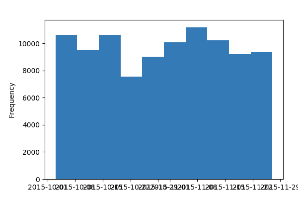

device_id  
Categorical

| Distinct count | 17887 |
| --- | --- |
| Unique (%) | 18.4% |
| Missing (%) | 0.0% |
| Missing (n) | 0 |

| JOVUEUUQPQVXO | 35 |
| --- | --- |
| XLJODRPXYKPRO | 34 |
| KRGUOOGZKNQRQ | 33 |
| Other values (17884) | 97239 |

Toggle details

| Value | Count | Frequency (%) |  |
| --- | --- | --- | --- |
| JOVUEUUQPQVXO | 35 | 0.0% |  |
| XLJODRPXYKPRO | 34 | 0.0% |  |
| KRGUOOGZKNQRQ | 33 | 0.0% |  |
| KQMNMACBAEKPP | 32 | 0.0% |  |
| OMCIHDOOQWZIG | 30 | 0.0% |  |
| ZOWALYNDHBLEO | 30 | 0.0% |  |
| YFDXMHNWCZJJY | 30 | 0.0% |  |
| NWJQZEWLIUYHW | 30 | 0.0% |  |
| JFFJFHRLPHJTQ | 29 | 0.0% |  |
| DWLKFOPPHLUFR | 28 | 0.0% |  |
| Other values (17877) | 97030 | 99.7% |  |

is_referral  
Boolean

| Distinct count | 2 |
| --- | --- |
| Unique (%) | 0.0% |
| Missing (%) | 0.0% |
| Missing (n) | 0 |

| Mean | 0.28782 |
| --- | --- |

| 0 | 69324 |
| --- | --- |
| 1 | 28017 |

Toggle details

| Value | Count | Frequency (%) |  |
| --- | --- | --- | --- |
| 0 | 69324 | 71.2% |  |
| 1 | 28017 | 28.8% |  |

money_spent  
Numeric

| Distinct count | 165 |
| --- | --- |
| Unique (%) | 0.2% |
| Missing (%) | 0.0% |
| Missing (n) | 0 |
| Infinite (%) | 0.0% |
| Infinite (n) | 0 |

| Mean | 44.692 |
| --- | --- |
| Minimum | 10 |
| Maximum | 220 |
| Zeros (%) | 0.0% |

Toggle details

**Statistics**

Quantile statistics

| Minimum | 10 |
| --- | --- |
| 5-th percentile | 14 |
| Q1 | 27 |
| Median | 42 |
| Q3 | 59 |
| 95-th percentile | 87 |
| Maximum | 220 |
| Range | 210 |
| Interquartile range | 32 |

Descriptive statistics

| Standard deviation | 22.792 |
| --- | --- |
| Coef of variation | 0.50997 |
| Kurtosis | 0.81907 |
| Mean | 44.692 |
| MAD | 18.19 |
| Skewness | 0.81873 |
| Sum | 4350399 |
| Variance | 519.47 |
| Memory size | 760.6 KiB |

**Histogram**

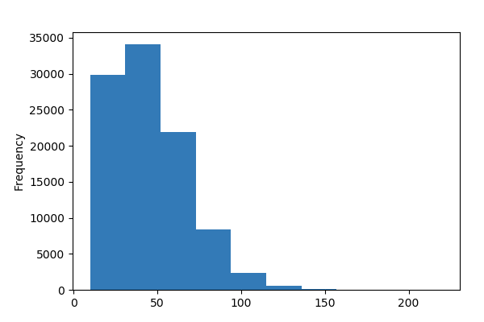

**Common Values**

| Value | Count | Frequency (%) |  |
| --- | --- | --- | --- |
| 34 | 1704 | 1.8% |  |
| 37 | 1689 | 1.7% |  |
| 39 | 1679 | 1.7% |  |
| 35 | 1679 | 1.7% |  |
| 28 | 1678 | 1.7% |  |
| 45 | 1675 | 1.7% |  |
| 41 | 1674 | 1.7% |  |
| 40 | 1673 | 1.7% |  |
| 33 | 1670 | 1.7% |  |
| 32 | 1664 | 1.7% |  |
| Other values (155) | 80556 | 82.8% |  |

**Extreme Values**

Minimum 5 values

| Value | Count | Frequency (%) |  |
| --- | --- | --- | --- |
| 10 | 1077 | 1.1% |  |
| 11 | 1193 | 1.2% |  |
| 12 | 1215 | 1.2% |  |
| 13 | 1247 | 1.3% |  |
| 14 | 1346 | 1.4% |  |

Maximum 5 values

| Value | Count | Frequency (%) |  |
| --- | --- | --- | --- |
| 188 | 1 | 0.0% |  |
| 192 | 1 | 0.0% |  |
| 195 | 1 | 0.0% |  |
| 198 | 1 | 0.0% |  |
| 220 | 1 | 0.0% |  |

user_id  
Numeric

| Distinct count | 18809 |
| --- | --- |
| Unique (%) | 19.3% |
| Missing (%) | 0.0% |
| Missing (n) | 0 |
| Infinite (%) | 0.0% |
| Infinite (n) | 0 |

| Mean | 6354.8 |
| --- | --- |
| Minimum | 1 |
| Maximum | 20000 |
| Zeros (%) | 0.0% |

Toggle details

**Statistics**

Quantile statistics

| Minimum | 1 |
| --- | --- |
| 5-th percentile | 414 |
| Q1 | 2020 |
| Median | 4053 |
| Q3 | 10286 |
| 95-th percentile | 18055 |
| Maximum | 20000 |
| Range | 19999 |
| Interquartile range | 8266 |

Descriptive statistics

| Standard deviation | 5683 |
| --- | --- |
| Coef of variation | 0.89428 |
| Kurtosis | -0.4139 |
| Mean | 6354.8 |
| MAD | 4795.8 |
| Skewness | 0.94548 |
| Sum | 618582687 |
| Variance | 32296000 |
| Memory size | 760.6 KiB |

**Histogram**

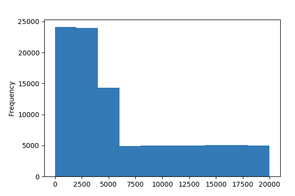

**Common Values**

| Value | Count | Frequency (%) |  |
| --- | --- | --- | --- |
| 1107 | 27 | 0.0% |  |
| 1532 | 25 | 0.0% |  |
| 2236 | 25 | 0.0% |  |
| 1347 | 24 | 0.0% |  |
| 1424 | 24 | 0.0% |  |
| 1168 | 24 | 0.0% |  |
| 1483 | 24 | 0.0% |  |
| 2208 | 24 | 0.0% |  |
| 3592 | 24 | 0.0% |  |
| 4869 | 23 | 0.0% |  |
| Other values (18799) | 97097 | 99.7% |  |

**Extreme Values**

Minimum 5 values

| Value | Count | Frequency (%) |  |
| --- | --- | --- | --- |
| 1 | 9 | 0.0% |  |
| 2 | 14 | 0.0% |  |
| 3 | 15 | 0.0% |  |
| 4 | 13 | 0.0% |  |
| 5 | 6 | 0.0% |  |

Maximum 5 values

| Value | Count | Frequency (%) |  |
| --- | --- | --- | --- |
| 19996 | 2 | 0.0% |  |
| 19997 | 2 | 0.0% |  |
| 19998 | 2 | 0.0% |  |
| 19999 | 5 | 0.0% |  |
| 20000 | 2 | 0.0% |  |

weekday  
Categorical

| Distinct count | 7 |
| --- | --- |
| Unique (%) | 0.0% |
| Missing (%) | 0.0% |
| Missing (n) | 0 |

| Sunday | 25207 |
| --- | --- |
| Saturday | 25087 |
| Monday | 9573 |
| Other values (4) | 37474 |

Toggle details

| Value | Count | Frequency (%) |  |
| --- | --- | --- | --- |
| Sunday | 25207 | 25.9% |  |
| Saturday | 25087 | 25.8% |  |
| Monday | 9573 | 9.8% |  |
| Thursday | 9511 | 9.8% |  |
| Tuesday | 9413 | 9.7% |  |
| Friday | 9296 | 9.5% |  |
| Wednesday | 9254 | 9.5% |  |

Correlations

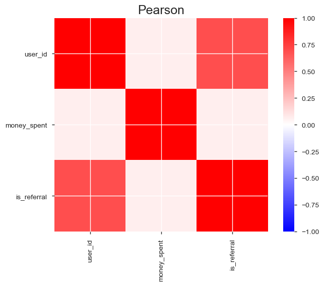

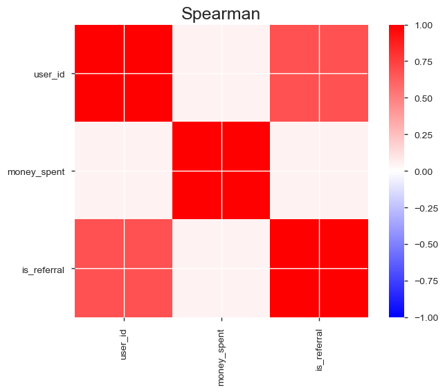

Sample

|  | user_id | date | country | money_spent | is_referral | device_id | weekday |
| --- | --- | --- | --- | --- | --- | --- | --- |
| 0 | 2 | 2015-10-03 | FR | 65 | 0 | EVDCJTZMVMJDG | Saturday |
| 1 | 3 | 2015-10-03 | CA | 54 | 0 | WUBZFTVKXGQQX | Saturday |
| 2 | 6 | 2015-10-03 | FR | 35 | 0 | CBAPCJRTFNUJG | Saturday |
| 3 | 7 | 2015-10-03 | UK | 73 | 0 | PRGXJZAJKMXRH | Saturday |
| 4 | 7 | 2015-10-03 | MX | 35 | 0 | PRGXJZAJKMXRH | Saturday |

```python
# Generating report to check :
# 1. How many observations we have
# 2. If there are null values
# 3. General infos on the dataset
pandas_profiling.ProfileReport(dataset)
```

#### Notes from the report :

- No null value
- A few duplicate rows (24 / 97 341 should not be significant though but can be worth it to have a look)
- No obvious outlier in the dataset
- Most transactions happen in the weekend (over 50%)
- The same user_id can appear several times
- The same device_id can appear several times

##### Let's quickly look at duplicate

```python
dataset[dataset.duplicated(keep = False)].head(10)
```

|  | user_id | date | country | money_spent | is_referral | device_id | weekday |
| --- | --- | --- | --- | --- | --- | --- | --- |
| 1524 | 2557 | 2015-10-03 | DE | 37 | 0 | IACHUGISDMNKC | Saturday |
| 1525 | 2557 | 2015-10-03 | DE | 37 | 0 | IACHUGISDMNKC | Saturday |
| 2707 | 4463 | 2015-10-03 | DE | 21 | 0 | XLXGQZAPCDEFS | Saturday |
| 2708 | 4463 | 2015-10-03 | DE | 21 | 0 | XLXGQZAPCDEFS | Saturday |
| 9454 | 4771 | 2015-10-07 | FR | 54 | 0 | KNAEYOYYDVDJY | Wednesday |
| 9455 | 4771 | 2015-10-07 | FR | 54 | 0 | KNAEYOYYDVDJY | Wednesday |
| 10056 | 2466 | 2015-10-08 | US | 23 | 0 | FIBYLEPRDNHPO | Thursday |
| 10057 | 2466 | 2015-10-08 | US | 23 | 0 | FIBYLEPRDNHPO | Thursday |
| 15180 | 674 | 2015-10-11 | MX | 40 | 0 | NOPCAMOTUQMPM | Sunday |
| 15181 | 674 | 2015-10-11 | MX | 40 | 0 | NOPCAMOTUQMPM | Sunday |

```python
# It looks like these duplicates are double entries. For the sake of data cleanliness we are going to remove them
# If we had access to management we could quickly confirm whether they should be removed
dataset.drop_duplicates(keep = "first", inplace = True)
```

##### Let's see if some user_id use several devices and if one device is used by several device_id

```python
# We group by user_id and devide_id
df_groupby = dataset.groupby(by=["user_id","device_id"]).count().reset_index(level=1)

# Then we groupby resulting datset by user_id
df_groupby = df_groupby.groupby(by=df_groupby.index).count()

print("number of user_id using at least 2 devices: {}".format(len(df_groupby[df_groupby.device_id >1])))

# We group by device_id and user_id
df_groupby = dataset.groupby(by=["device_id","user_id"]).count().reset_index(level=1)

# Then we groupby resulting datset by device_id
df_groupby = df_groupby.groupby(by=df_groupby.index).count()

print("number of device_id with at least 2 user_id: {}".format(len(df_groupby[df_groupby.user_id >1])))
```

```
number of user_id using at least 2 devices: 3883
number of device_id with at least 2 user_id: 3988
```

##### Let's see if some user_id can be booked in the system both as referred customers and as non referred customers

```python
# We group by user_id and is_referral
df_groupby = dataset.groupby(by=["user_id","is_referral"]).count().reset_index(level=1)

# Then we group resulting dataset by device_id
df_groupby = df_groupby.groupby(by=df_groupby.index).count()
print( "number of user_id booked in the system both as referral and not referral: {}".format(len(df_groupby[df_groupby.is_referral > 1])))
```

```
number of user_id booked in the system both as referral and not referral: 5857
```

##### It appears that some user_id are booked both as referral and not referral. Le't see if one user_id can be mentionned several times as referral

```python
# We filter on is_referral
df_groupby = dataset[dataset.is_referral == 1]

# We group by user_id
df_groupby = df_groupby.groupby(by=["user_id"]).count()

print( "number of user_id with more than one referral: {}".format(len(df_groupby[df_groupby.is_referral > 1])))

df_groupby.head(10)
```

```
number of user_id with more than one referral: 8319
```

| user_id | date | country | money_spent | is_referral | device_id | weekday |
| --- | --- | --- | --- | --- | --- | --- |
| 5001 | 2 | 2 | 2 | 2 | 2 | 2 |
| 5002 | 1 | 1 | 1 | 1 | 1 | 1 |
| 5003 | 2 | 2 | 2 | 2 | 2 | 2 |
| 5004 | 1 | 1 | 1 | 1 | 1 | 1 |
| 5005 | 2 | 2 | 2 | 2 | 2 | 2 |
| 5006 | 3 | 3 | 3 | 3 | 3 | 3 |
| 5008 | 1 | 1 | 1 | 1 | 1 | 1 |
| 5011 | 4 | 4 | 4 | 4 | 4 | 4 |
| 5013 | 4 | 4 | 4 | 4 | 4 | 4 |
| 5016 | 2 | 2 | 2 | 2 | 2 | 2 |

```python
# Sample of user_id with several referral
dataset.loc[dataset.user_id.isin(["5002","5006","5011","5016"])].sort_values(by="user_id")
```

|  | user_id | date | country | money_spent | is_referral | device_id | weekday |
| --- | --- | --- | --- | --- | --- | --- | --- |
| 70080 | 5002 | 2015-11-12 | FR | 22 | 1 | AAFWFCPHRVTTE | Thursday |
| 73045 | 5002 | 2015-11-14 | CA | 94 | 0 | AAFWFCPHRVTTE | Saturday |
| 81458 | 5006 | 2015-11-18 | US | 61 | 1 | XRPEUJCDGXGAF | Wednesday |
| 85613 | 5006 | 2015-11-21 | CH | 35 | 1 | XRPEUJCDGXGAF | Saturday |
| 85614 | 5006 | 2015-11-21 | CA | 25 | 1 | XRPEUJCDGXGAF | Saturday |
| 55284 | 5011 | 2015-11-03 | US | 34 | 1 | QWHTFNCGOCZTB | Tuesday |
| 55285 | 5011 | 2015-11-03 | MX | 25 | 1 | QWHTFNCGOCZTB | Tuesday |
| 73046 | 5011 | 2015-11-14 | FR | 30 | 1 | QWHTFNCGOCZTB | Saturday |
| 79147 | 5011 | 2015-11-16 | UK | 59 | 0 | QWHTFNCGOCZTB | Monday |
| 80321 | 5011 | 2015-11-17 | DE | 29 | 1 | QWHTFNCGOCZTB | Tuesday |
| 48170 | 5016 | 2015-10-31 | DE | 45 | 1 | OGAZARJAGCPUQ | Saturday |
| 76379 | 5016 | 2015-11-15 | US | 15 | 1 | OGAZARJAGCPUQ | Sunday |

##### At this stage, it is hard for us to understand the rule under which a given user_id is booked as a referral or not. We would discuss with Management to understand that information which is key to our analyses

Indeed, based on above sample :

[output not shown]

Given we lack the information to correctly understand the data, we are going to conduct our analysis on the "worst case" scenario, ie. that each transaction indicated as "is_referral" implied that a $10 discount was given to a referee

We were instructed that the referall program started in October 31st. To assess the impact of this program we are going to split the data in two datasets, one containing data before the referral and one data after referral

```python
df_bf_ref = dataset[dataset.date<datetime.datetime(2015,10,31)]
df_aft_ref = dataset[dataset.date>=datetime.datetime(2015,10,31)]
```

Overview

Dataset info

| Number of variables | 8 |
| --- | --- |
| Number of observations | 47320 |
| Total Missing (%) | 0.0% |
| Total size in memory | 2.9 MiB |
| Average record size in memory | 64.0 B |

Variables types

| Numeric | 3 |
| --- | --- |
| Categorical | 3 |
| Boolean | 0 |
| Date | 1 |
| Text (Unique) | 0 |
| Rejected | 1 |
| Unsupported | 0 |

Warnings

- `device_id` has a high cardinality: 7317 distinct values Warning

- `is_referral` has constant value 0 Rejected

Variables

country  
Categorical

| Distinct count | 9 |
| --- | --- |
| Unique (%) | 0.0% |
| Missing (%) | 0.0% |
| Missing (n) | 0 |

| US | 7902 |
| --- | --- |
| UK | 7394 |
| FR | 6833 |
| Other values (6) | 25191 |

Toggle details

| Value | Count | Frequency (%) |  |
| --- | --- | --- | --- |
| US | 7902 | 16.7% |  |
| UK | 7394 | 15.6% |  |
| FR | 6833 | 14.4% |  |
| DE | 6494 | 13.7% |  |
| IT | 5062 | 10.7% |  |
| CA | 4960 | 10.5% |  |
| ES | 4384 | 9.3% |  |
| MX | 3540 | 7.5% |  |
| CH | 751 | 1.6% |  |

date  
Date

| Distinct count | 28 |
| --- | --- |
| Unique (%) | 0.1% |
| Missing (%) | 0.0% |
| Missing (n) | 0 |
| Infinite (%) | 0.0% |
| Infinite (n) | 0 |

| Minimum | 2015-10-03 00:00:00 |
| --- | --- |
| Maximum | 2015-10-30 00:00:00 |

Toggle details

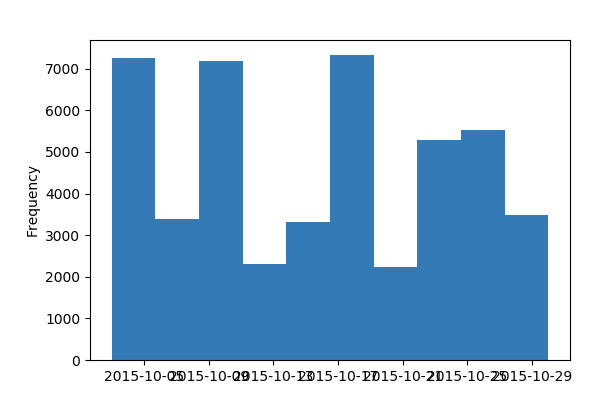

device_id  
Categorical

| Distinct count | 7317 |
| --- | --- |
| Unique (%) | 15.5% |
| Missing (%) | 0.0% |
| Missing (n) | 0 |

| JOVUEUUQPQVXO | 29 |
| --- | --- |
| XLJODRPXYKPRO | 28 |
| JFFJFHRLPHJTQ | 25 |
| Other values (7314) | 47238 |

Toggle details

| Value | Count | Frequency (%) |  |
| --- | --- | --- | --- |
| JOVUEUUQPQVXO | 29 | 0.1% |  |
| XLJODRPXYKPRO | 28 | 0.1% |  |
| JFFJFHRLPHJTQ | 25 | 0.1% |  |
| EKNUIDOZRGWFA | 24 | 0.1% |  |
| KQMNMACBAEKPP | 24 | 0.1% |  |
| OMCIHDOOQWZIG | 24 | 0.1% |  |
| MQOQCPFOXZNZK | 24 | 0.1% |  |
| XXGVAODEWTRBF | 24 | 0.1% |  |
| OMJJTERZAULQL | 24 | 0.1% |  |
| NWJQZEWLIUYHW | 23 | 0.0% |  |
| Other values (7307) | 47071 | 99.5% |  |

index  
Numeric

| Distinct count | 47320 |
| --- | --- |
| Unique (%) | 100.0% |
| Missing (%) | 0.0% |
| Missing (n) | 0 |
| Infinite (%) | 0.0% |
| Infinite (n) | 0 |

| Mean | 23669 |
| --- | --- |
| Minimum | 0 |
| Maximum | 47340 |
| Zeros (%) | 0.0% |

Toggle details

**Statistics**

Quantile statistics

| Minimum | 0 |
| --- | --- |
| 5-th percentile | 2367 |
| Q1 | 11834 |
| Median | 23668 |
| Q3 | 35505 |
| 95-th percentile | 44973 |
| Maximum | 47340 |
| Range | 47340 |
| Interquartile range | 23672 |

Descriptive statistics

| Standard deviation | 13667 |
| --- | --- |
| Coef of variation | 0.5774 |
| Kurtosis | -1.2001 |
| Mean | 23669 |
| MAD | 11836 |
| Skewness | 8.0152e-05 |
| Sum | 1120034234 |
| Variance | 186780000 |
| Memory size | 369.8 KiB |

**Histogram**

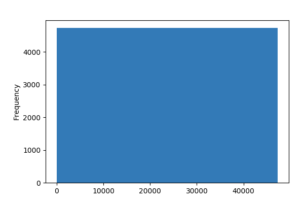

**Common Values**

| Value | Count | Frequency (%) |  |
| --- | --- | --- | --- |
| 2047 | 1 | 0.0% |  |
| 9550 | 1 | 0.0% |  |
| 21856 | 1 | 0.0% |  |
| 44383 | 1 | 0.0% |  |
| 42334 | 1 | 0.0% |  |
| 46428 | 1 | 0.0% |  |
| 36187 | 1 | 0.0% |  |
| 34138 | 1 | 0.0% |  |
| 40281 | 1 | 0.0% |  |
| 38232 | 1 | 0.0% |  |
| Other values (47310) | 47310 | 100.0% |  |

**Extreme Values**

Minimum 5 values

| Value | Count | Frequency (%) |  |
| --- | --- | --- | --- |
| 0 | 1 | 0.0% |  |
| 1 | 1 | 0.0% |  |
| 2 | 1 | 0.0% |  |
| 3 | 1 | 0.0% |  |
| 4 | 1 | 0.0% |  |

Maximum 5 values

| Value | Count | Frequency (%) |  |
| --- | --- | --- | --- |
| 47336 | 1 | 0.0% |  |
| 47337 | 1 | 0.0% |  |
| 47338 | 1 | 0.0% |  |
| 47339 | 1 | 0.0% |  |
| 47340 | 1 | 0.0% |  |

is_referral  
Constant

*This variable is constant and should be ignored for analysis*

| Constant value | 0 |
| --- | --- |

money_spent  
Numeric

| Distinct count | 135 |
| --- | --- |
| Unique (%) | 0.3% |
| Missing (%) | 0.0% |
| Missing (n) | 0 |
| Infinite (%) | 0.0% |
| Infinite (n) | 0 |

| Mean | 42.386 |
| --- | --- |
| Minimum | 10 |
| Maximum | 177 |
| Zeros (%) | 0.0% |

Toggle details

**Statistics**

Quantile statistics

| Minimum | 10 |
| --- | --- |
| 5-th percentile | 13 |
| Q1 | 26 |
| Median | 40 |
| Q3 | 55 |
| 95-th percentile | 80 |
| Maximum | 177 |
| Range | 167 |
| Interquartile range | 29 |

Descriptive statistics

| Standard deviation | 20.683 |
| --- | --- |
| Coef of variation | 0.48796 |
| Kurtosis | 0.41606 |
| Mean | 42.386 |
| MAD | 16.658 |
| Skewness | 0.69894 |
| Sum | 2005687 |
| Variance | 427.77 |
| Memory size | 369.8 KiB |

**Histogram**

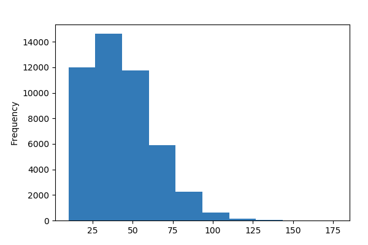

**Common Values**

| Value | Count | Frequency (%) |  |
| --- | --- | --- | --- |
| 37 | 906 | 1.9% |  |
| 28 | 902 | 1.9% |  |
| 35 | 882 | 1.9% |  |
| 32 | 880 | 1.9% |  |
| 41 | 874 | 1.8% |  |
| 40 | 870 | 1.8% |  |
| 26 | 868 | 1.8% |  |
| 34 | 868 | 1.8% |  |
| 33 | 865 | 1.8% |  |
| 30 | 864 | 1.8% |  |
| Other values (125) | 38541 | 81.4% |  |

**Extreme Values**

Minimum 5 values

| Value | Count | Frequency (%) |  |
| --- | --- | --- | --- |
| 10 | 542 | 1.1% |  |
| 11 | 622 | 1.3% |  |
| 12 | 618 | 1.3% |  |
| 13 | 624 | 1.3% |  |
| 14 | 689 | 1.5% |  |

Maximum 5 values

| Value | Count | Frequency (%) |  |
| --- | --- | --- | --- |
| 146 | 1 | 0.0% |  |
| 147 | 2 | 0.0% |  |
| 148 | 1 | 0.0% |  |
| 174 | 1 | 0.0% |  |
| 177 | 1 | 0.0% |  |

user_id  
Numeric

| Distinct count | 5000 |
| --- | --- |
| Unique (%) | 10.6% |
| Missing (%) | 0.0% |
| Missing (n) | 0 |
| Infinite (%) | 0.0% |
| Infinite (n) | 0 |

| Mean | 2491.3 |
| --- | --- |
| Minimum | 1 |
| Maximum | 5000 |
| Zeros (%) | 0.0% |

Toggle details

**Statistics**

Quantile statistics

| Minimum | 1 |
| --- | --- |
| 5-th percentile | 251 |
| Q1 | 1248 |
| Median | 2486 |
| Q3 | 3741 |
| 95-th percentile | 4746 |
| Maximum | 5000 |
| Range | 4999 |
| Interquartile range | 2493 |

Descriptive statistics

| Standard deviation | 1440.1 |
| --- | --- |
| Coef of variation | 0.57803 |
| Kurtosis | -1.1978 |
| Mean | 2491.3 |
| MAD | 1248 |
| Skewness | 0.011696 |
| Sum | 117890127 |
| Variance | 2073800 |
| Memory size | 369.8 KiB |

**Histogram**

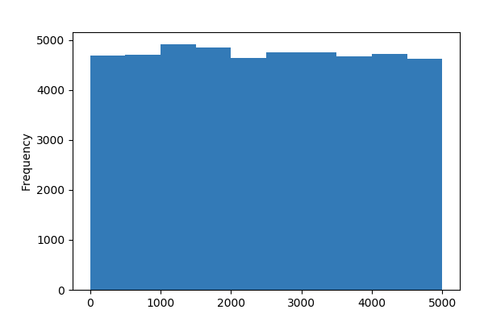

**Common Values**

| Value | Count | Frequency (%) |  |
| --- | --- | --- | --- |
| 1107 | 22 | 0.0% |  |
| 3964 | 21 | 0.0% |  |
| 3670 | 21 | 0.0% |  |
| 2236 | 21 | 0.0% |  |
| 1483 | 20 | 0.0% |  |
| 1532 | 20 | 0.0% |  |
| 1424 | 20 | 0.0% |  |
| 1168 | 20 | 0.0% |  |
| 3744 | 20 | 0.0% |  |
| 4446 | 20 | 0.0% |  |
| Other values (4990) | 47115 | 99.6% |  |

**Extreme Values**

Minimum 5 values

| Value | Count | Frequency (%) |  |
| --- | --- | --- | --- |
| 1 | 6 | 0.0% |  |
| 2 | 12 | 0.0% |  |
| 3 | 14 | 0.0% |  |
| 4 | 12 | 0.0% |  |
| 5 | 5 | 0.0% |  |

Maximum 5 values

| Value | Count | Frequency (%) |  |
| --- | --- | --- | --- |
| 4996 | 10 | 0.0% |  |
| 4997 | 12 | 0.0% |  |
| 4998 | 15 | 0.0% |  |
| 4999 | 7 | 0.0% |  |
| 5000 | 9 | 0.0% |  |

weekday  
Categorical

| Distinct count | 7 |
| --- | --- |
| Unique (%) | 0.0% |
| Missing (%) | 0.0% |
| Missing (n) | 0 |

| Sunday | 12375 |
| --- | --- |
| Saturday | 12200 |
| Monday | 4638 |
| Other values (4) | 18107 |

Toggle details

| Value | Count | Frequency (%) |  |
| --- | --- | --- | --- |
| Sunday | 12375 | 26.2% |  |
| Saturday | 12200 | 25.8% |  |
| Monday | 4638 | 9.8% |  |
| Tuesday | 4609 | 9.7% |  |
| Thursday | 4592 | 9.7% |  |
| Friday | 4493 | 9.5% |  |
| Wednesday | 4413 | 9.3% |  |

Correlations

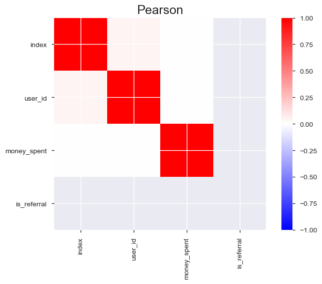

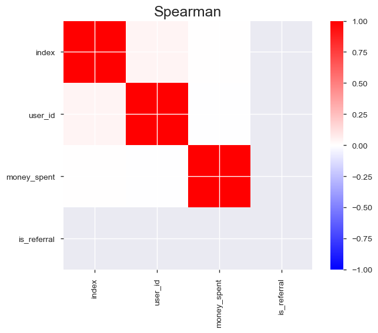

Sample

|  | user_id | date | country | money_spent | is_referral | device_id | weekday |
| --- | --- | --- | --- | --- | --- | --- | --- |
| 0 | 2 | 2015-10-03 | FR | 65 | 0 | EVDCJTZMVMJDG | Saturday |
| 1 | 3 | 2015-10-03 | CA | 54 | 0 | WUBZFTVKXGQQX | Saturday |
| 2 | 6 | 2015-10-03 | FR | 35 | 0 | CBAPCJRTFNUJG | Saturday |
| 3 | 7 | 2015-10-03 | UK | 73 | 0 | PRGXJZAJKMXRH | Saturday |
| 4 | 7 | 2015-10-03 | MX | 35 | 0 | PRGXJZAJKMXRH | Saturday |

```python
# We can look at report for these two sub_datasets
pandas_profiling.ProfileReport(df_bf_ref)
```

Overview

Dataset info

| Number of variables | 8 |
| --- | --- |
| Number of observations | 49997 |
| Total Missing (%) | 0.0% |
| Total size in memory | 3.1 MiB |
| Average record size in memory | 64.0 B |

Variables types

| Numeric | 3 |
| --- | --- |
| Categorical | 3 |
| Boolean | 1 |
| Date | 1 |
| Text (Unique) | 0 |
| Rejected | 0 |
| Unsupported | 0 |

Warnings

- `device_id` has a high cardinality: 15067 distinct values Warning

Variables

country  
Categorical

| Distinct count | 9 |
| --- | --- |
| Unique (%) | 0.0% |
| Missing (%) | 0.0% |
| Missing (n) | 0 |

| FR | 8560 |
| --- | --- |
| UK | 8092 |
| US | 7375 |
| Other values (6) | 25970 |

Toggle details

| Value | Count | Frequency (%) |  |
| --- | --- | --- | --- |
| FR | 8560 | 17.1% |  |
| UK | 8092 | 16.2% |  |
| US | 7375 | 14.8% |  |
| IT | 6381 | 12.8% |  |
| ES | 5446 | 10.9% |  |
| DE | 4593 | 9.2% |  |
| MX | 4592 | 9.2% |  |
| CA | 4480 | 9.0% |  |
| CH | 478 | 1.0% |  |

date  
Date

| Distinct count | 28 |
| --- | --- |
| Unique (%) | 0.1% |
| Missing (%) | 0.0% |
| Missing (n) | 0 |
| Infinite (%) | 0.0% |
| Infinite (n) | 0 |

| Minimum | 2015-10-31 00:00:00 |
| --- | --- |
| Maximum | 2015-11-27 00:00:00 |

Toggle details

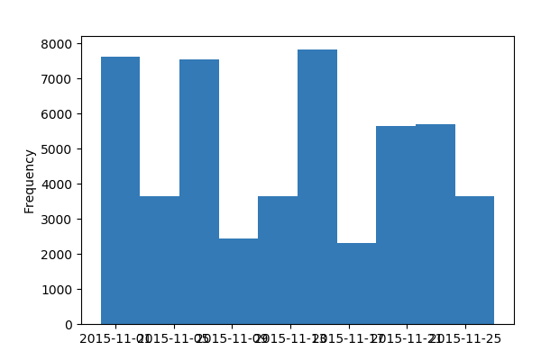

device_id  
Categorical

| Distinct count | 15067 |
| --- | --- |
| Unique (%) | 30.1% |
| Missing (%) | 0.0% |
| Missing (n) | 0 |

| FOLFCBHQFAEPV | 22 |
| --- | --- |
| DEPBWTYADPNYI | 20 |
| YDIVKRAVFYJFO | 20 |
| Other values (15064) | 49935 |

Toggle details

| Value | Count | Frequency (%) |  |
| --- | --- | --- | --- |
| FOLFCBHQFAEPV | 22 | 0.0% |  |
| DEPBWTYADPNYI | 20 | 0.0% |  |
| YDIVKRAVFYJFO | 20 | 0.0% |  |
| TRFMIUAPPWHEH | 20 | 0.0% |  |
| XDJSPACIBSIPB | 19 | 0.0% |  |
| DLXRTYWSFWWMM | 19 | 0.0% |  |
| KRCJDOKOJKBRI | 19 | 0.0% |  |
| XWVVBDDZUCTWJ | 18 | 0.0% |  |
| AIXHODKGWTYVG | 18 | 0.0% |  |
| TSRGFMPUATAII | 18 | 0.0% |  |
| Other values (15057) | 49804 | 99.6% |  |

index  
Numeric

| Distinct count | 49997 |
| --- | --- |
| Unique (%) | 100.0% |
| Missing (%) | 0.0% |
| Missing (n) | 0 |
| Infinite (%) | 0.0% |
| Infinite (n) | 0 |

| Mean | 72341 |
| --- | --- |
| Minimum | 47341 |
| Maximum | 97340 |
| Zeros (%) | 0.0% |

Toggle details

**Statistics**

Quantile statistics

| Minimum | 47341 |
| --- | --- |
| 5-th percentile | 49841 |
| Q1 | 59842 |
| Median | 72341 |
| Q3 | 84840 |
| 95-th percentile | 94840 |
| Maximum | 97340 |
| Range | 49999 |
| Interquartile range | 24998 |

Descriptive statistics

| Standard deviation | 14434 |
| --- | --- |
| Coef of variation | 0.19953 |
| Kurtosis | -1.1999 |
| Mean | 72341 |
| MAD | 12500 |
| Skewness | -3.7213e-05 |
| Sum | 3616825431 |
| Variance | 208340000 |
| Memory size | 390.7 KiB |

**Histogram**

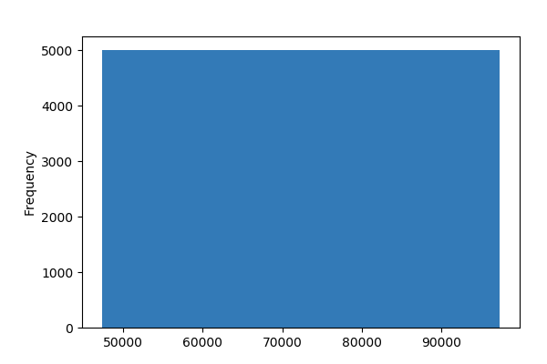

**Common Values**

| Value | Count | Frequency (%) |  |
| --- | --- | --- | --- |
| 67583 | 1 | 0.0% |  |
| 73001 | 1 | 0.0% |  |
| 93511 | 1 | 0.0% |  |
| 91462 | 1 | 0.0% |  |
| 95556 | 1 | 0.0% |  |
| 85315 | 1 | 0.0% |  |
| 83266 | 1 | 0.0% |  |
| 89409 | 1 | 0.0% |  |
| 87360 | 1 | 0.0% |  |
| 48445 | 1 | 0.0% |  |
| Other values (49987) | 49987 | 100.0% |  |

**Extreme Values**

Minimum 5 values

| Value | Count | Frequency (%) |  |
| --- | --- | --- | --- |
| 47341 | 1 | 0.0% |  |
| 47342 | 1 | 0.0% |  |
| 47343 | 1 | 0.0% |  |
| 47344 | 1 | 0.0% |  |
| 47345 | 1 | 0.0% |  |

Maximum 5 values

| Value | Count | Frequency (%) |  |
| --- | --- | --- | --- |
| 97336 | 1 | 0.0% |  |
| 97337 | 1 | 0.0% |  |
| 97338 | 1 | 0.0% |  |
| 97339 | 1 | 0.0% |  |
| 97340 | 1 | 0.0% |  |

is_referral  
Boolean

| Distinct count | 2 |
| --- | --- |
| Unique (%) | 0.0% |
| Missing (%) | 0.0% |
| Missing (n) | 0 |

| Mean | 0.56033 |
| --- | --- |

| 1 | 28015 |
| --- | --- |
| 0 | 21982 |

Toggle details

| Value | Count | Frequency (%) |  |
| --- | --- | --- | --- |
| 1 | 28015 | 56.0% |  |
| 0 | 21982 | 44.0% |  |

money_spent  
Numeric

| Distinct count | 164 |
| --- | --- |
| Unique (%) | 0.3% |
| Missing (%) | 0.0% |
| Missing (n) | 0 |
| Infinite (%) | 0.0% |
| Infinite (n) | 0 |

| Mean | 46.88 |
| --- | --- |
| Minimum | 10 |
| Maximum | 220 |
| Zeros (%) | 0.0% |

Toggle details

**Statistics**

Quantile statistics

| Minimum | 10 |
| --- | --- |
| 5-th percentile | 14 |
| Q1 | 28 |
| Median | 44 |
| Q3 | 62 |
| 95-th percentile | 92 |
| Maximum | 220 |
| Range | 210 |
| Interquartile range | 34 |

Descriptive statistics

| Standard deviation | 24.425 |
| --- | --- |
| Coef of variation | 0.521 |
| Kurtosis | 0.74979 |
| Mean | 46.88 |
| MAD | 19.512 |
| Skewness | 0.8174 |
| Sum | 2343881 |
| Variance | 596.56 |
| Memory size | 390.7 KiB |

**Histogram**

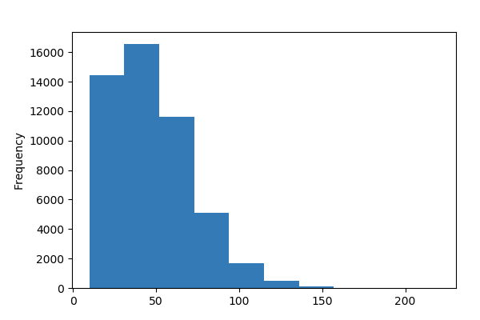

**Common Values**

| Value | Count | Frequency (%) |  |
| --- | --- | --- | --- |
| 34 | 836 | 1.7% |  |
| 45 | 824 | 1.6% |  |
| 39 | 816 | 1.6% |  |
| 31 | 814 | 1.6% |  |
| 36 | 811 | 1.6% |  |
| 33 | 805 | 1.6% |  |
| 38 | 803 | 1.6% |  |
| 40 | 802 | 1.6% |  |
| 41 | 800 | 1.6% |  |
| 35 | 796 | 1.6% |  |
| Other values (154) | 41890 | 83.8% |  |

**Extreme Values**

Minimum 5 values

| Value | Count | Frequency (%) |  |
| --- | --- | --- | --- |
| 10 | 535 | 1.1% |  |
| 11 | 571 | 1.1% |  |
| 12 | 597 | 1.2% |  |
| 13 | 622 | 1.2% |  |
| 14 | 657 | 1.3% |  |

Maximum 5 values

| Value | Count | Frequency (%) |  |
| --- | --- | --- | --- |
| 188 | 1 | 0.0% |  |
| 192 | 1 | 0.0% |  |
| 195 | 1 | 0.0% |  |
| 198 | 1 | 0.0% |  |
| 220 | 1 | 0.0% |  |

user_id  
Numeric

| Distinct count | 18397 |
| --- | --- |
| Unique (%) | 36.8% |
| Missing (%) | 0.0% |
| Missing (n) | 0 |
| Infinite (%) | 0.0% |
| Infinite (n) | 0 |

| Mean | 10013 |
| --- | --- |
| Minimum | 1 |
| Maximum | 20000 |
| Zeros (%) | 0.0% |

Toggle details

**Statistics**

Quantile statistics

| Minimum | 1 |
| --- | --- |
| 5-th percentile | 1017 |
| Q1 | 4961 |
| Median | 10032 |
| Q3 | 15030 |
| 95-th percentile | 19036 |
| Maximum | 20000 |
| Range | 19999 |
| Interquartile range | 10069 |

Descriptive statistics

| Standard deviation | 5779.1 |
| --- | --- |
| Coef of variation | 0.57718 |
| Kurtosis | -1.2054 |
| Mean | 10013 |
| MAD | 5008.2 |
| Skewness | -0.0015582 |
| Sum | 500602314 |
| Variance | 33398000 |
| Memory size | 390.7 KiB |

**Histogram**

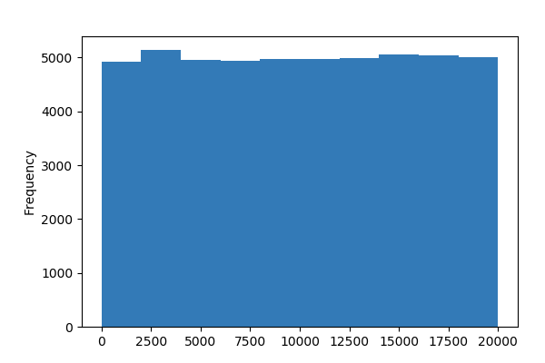

**Common Values**

| Value | Count | Frequency (%) |  |
| --- | --- | --- | --- |
| 19663 | 11 | 0.0% |  |
| 9803 | 10 | 0.0% |  |
| 11451 | 10 | 0.0% |  |
| 13785 | 10 | 0.0% |  |
| 14237 | 10 | 0.0% |  |
| 3430 | 9 | 0.0% |  |
| 9423 | 9 | 0.0% |  |
| 17627 | 9 | 0.0% |  |
| 9873 | 9 | 0.0% |  |
| 17460 | 9 | 0.0% |  |
| Other values (18387) | 49901 | 99.8% |  |

**Extreme Values**

Minimum 5 values

| Value | Count | Frequency (%) |  |
| --- | --- | --- | --- |
| 1 | 3 | 0.0% |  |
| 2 | 2 | 0.0% |  |
| 3 | 1 | 0.0% |  |
| 4 | 1 | 0.0% |  |
| 5 | 1 | 0.0% |  |

Maximum 5 values

| Value | Count | Frequency (%) |  |
| --- | --- | --- | --- |
| 19996 | 2 | 0.0% |  |
| 19997 | 2 | 0.0% |  |
| 19998 | 2 | 0.0% |  |
| 19999 | 5 | 0.0% |  |
| 20000 | 2 | 0.0% |  |

weekday  
Categorical

| Distinct count | 7 |
| --- | --- |
| Unique (%) | 0.0% |
| Missing (%) | 0.0% |
| Missing (n) | 0 |

| Saturday | 12878 |
| --- | --- |
| Sunday | 12829 |
| Monday | 4933 |
| Other values (4) | 19357 |

Toggle details

| Value | Count | Frequency (%) |  |
| --- | --- | --- | --- |
| Saturday | 12878 | 25.8% |  |
| Sunday | 12829 | 25.7% |  |
| Monday | 4933 | 9.9% |  |
| Thursday | 4915 | 9.8% |  |
| Wednesday | 4838 | 9.7% |  |
| Tuesday | 4802 | 9.6% |  |
| Friday | 4802 | 9.6% |  |

Correlations

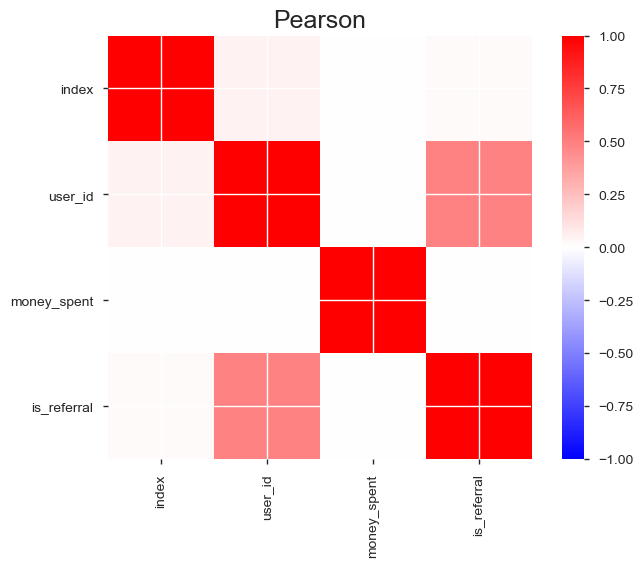

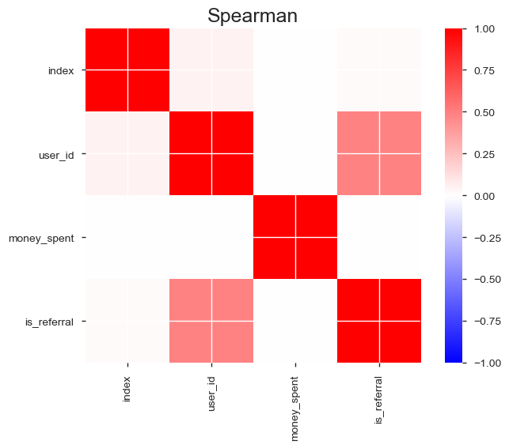

Sample

|  | user_id | date | country | money_spent | is_referral | device_id | weekday |
| --- | --- | --- | --- | --- | --- | --- | --- |
| 47341 | 21 | 2015-10-31 | US | 16 | 0 | GHWEHPGTKPKZA | Saturday |
| 47342 | 22 | 2015-10-31 | ES | 14 | 0 | YKGTJYXYDVYVR | Saturday |
| 47343 | 25 | 2015-10-31 | IT | 39 | 0 | BCVEWGFBYJMMK | Saturday |
| 47344 | 26 | 2015-10-31 | UK | 84 | 0 | PCXTGVBJDKPRE | Saturday |
| 47345 | 27 | 2015-10-31 | IT | 20 | 0 | XSTMGVICVRWMH | Saturday |

```python
pandas_profiling.ProfileReport(df_aft_ref)
```

#### Information we got from looking at these two reports side by side :

- Number of days is equivalent (28 days in each period) which guarantees same number of week_ends in each period
- Increase in number of transaction post referral campaign (50k post-referral vs 47k pre-referral ie. 6% increase)
- Increase in average money spent by transaction post referral campaign (€46.9 post-referral vs €42.4 pre-referral ie. 10.6% increase)
- There seems to be a strong variance of transaction based on date that would be interested to explore
- Distribution of countries has slightly changed (eg. strong increase of transaction from France)
- Assuming 1 user_id = 1 individual client, amount of individual clients has more than tripled post campaign (18 397 individual clients post-referral vs 5 000 pre-referral).

#### Analyses we want to do at this stage :

- Analysis of referred clients vs non referred clients
  - Average number of repeat transactions (ie. # of transaction by customer ID)
  - Average value per transaction
  - Distribution by country
- Understand revenue adjusted for referall paid
  - See total revenue per referred customer less 10 dollars

```python
# Let's create two datasets post-referral, splitting transactions from referred and non referred customers

df_referred = df_aft_ref[df_aft_ref.is_referral==1]
df_not_referred = df_aft_ref[df_aft_ref.is_referral==0]
```

##### We look at average value per transaction for referred customers vs. non referred customers

```python
print (f'average value per transaction for referred customers :${int(10*np.mean(df_referred.money_spent))/10}')
print (f'average value per transaction for non-referred customers :${int(10*np.mean(df_not_referred.money_spent))/10}')
```

```
average value per transaction for referred customers :$46.9
average value per transaction for non-referred customers :$46.7
```

#### Conclusion

average transaction value between referred and non referred customers is very similar

##### We compare total transaction volume and Revenue pre - program to total transaction volume post program to transaction volume non referred post program

```python
print(f"Total transaction volume pre-program: {len(df_bf_ref)} transactions. Revenue : ${sum(df_bf_ref.money_spent)}")
print(f"Total transaction non referred volume post-program: {len(df_not_referred)} transactions. Revenue : ${sum(df_not_referred.money_spent)}")
print(f"Total transaction volume post-program: {len(df_aft_ref)} transactions. Revenue : ${sum(df_aft_ref.money_spent)}")
print(f"Total revenue post-program net of referrals paid ${sum(df_aft_ref.money_spent) - 10*len(df_referred)} ")
print(f"Total net increase in revenue post vs. pre referral : {sum(df_aft_ref.money_spent) - 10*len(df_referred) - sum(df_bf_ref.money_spent) }" )
```

```
Total transaction volume pre-program: 47320 transactions. Revenue : $2005687
Total transaction non referred volume post-program: 21982 transactions. Revenue : $1028181
Total transaction volume post-program: 49997 transactions. Revenue : $2343881
Total revenue post-program net of referrals paid $2063731
Total net increase in revenue post vs. pre referral : 58044
```

#### Conclusions

[output not shown]

##### Now let's look at repeat purchases

We already know that # of individual clients has more than triple, which leads us to think that repeat purchase per customer has plummeted post campaign. Let's push the analysis further. To do that, we are going to compare average number of transaction per customer pre campaign and post campaign based on user_id. We would normally also want to look at average number of transactions per referred customer vs non referred, however we showed that a same customer can be booked as referred and not referred so our analysis will be flawed.

```python
df_groupby = df_bf_ref.groupby(by = "user_id").count()
print(f'average # of transaction per user_id pre-campaign : {np.mean(df_groupby.date)}')

df_groupby = df_aft_ref.groupby(by = "user_id").count()
print(f'average # of transaction per user_id post-campaign: {np.mean(df_groupby.date)}')

# Let's do the same analysis by device id

df_groupby = df_bf_ref.groupby(by = "device_id").count()
print(f'average # of transaction per device_id pre-campaign : {np.mean(df_groupby.date)}')

df_groupby = df_aft_ref.groupby(by = "device_id").count()
print(f'average # of transaction per device_id post-campaign: {np.mean(df_groupby.date)}')
```

[output not shown]

#### Conclusion

It appears indeed that transaction per user_id has strongly decreased. However if we correlate that to the change in number of transactions, it is likely that existing users have created new user ID or used their family user_id to benefit from the referral bonus.